# 1.1. How our algorithm works: High Level Overview

1. Identify Pairs (('TOTAL', 'UNILEVER'), ('SAP', 'ASML'), ('ALLIANZ', 'LVMH'))
2. Set thresholds and assign weight limits to thresholds
3. For each theshold $i$:
   - If z-value lies between threshold $i$ and the next highest threshold $i+1$, take a position in the pair up to the risk limit
   - If z-value is below the next lowest threshold $i-1$, then get out of positions in line with risk limits
4. Check hedging:
   - If hedging outside hedging thresholds, try to get out of positions to improve hedging if profitable
   - If not profitable to get out of position, prioritise improving other side of pair (setting signal)
5. Adaptive Thresholds:
   - Make a small change in threshold
   - Record profit/loss for next $n$ iterations
   - If profit goes up, continue chaging threshold in the same direction (as a function of the increase in profits)

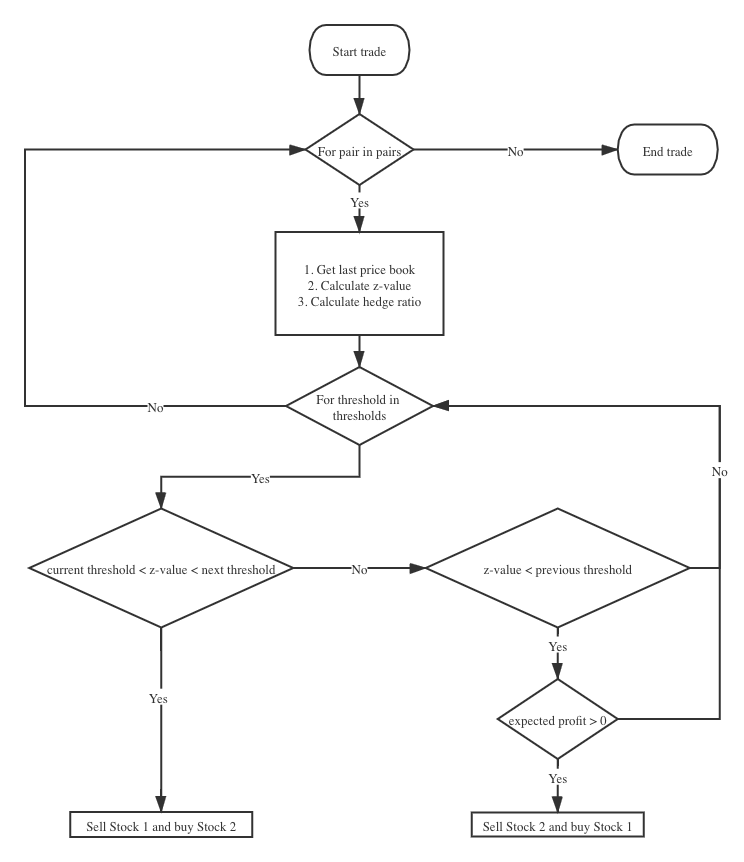

# 1.2. How our algorithm works: Risk Limits

#### Volume for second instrument in a pair:

`vol_st_2 = np.floor(min((bid_st_1.volume * hedge_ratio), ask_st_2.volume, limit[q] - df.loc[f'{pairs.index(i)}, {t}']['st_2_vol'], (limit[q] + df.loc[f'{pairs.index(i)}, {t}']['st_1_vol']) * hedge_ratio, 500 - pos[st_2], (500 + pos[st_1]) * hedge_ratio))`

#### Volume for first instrument in a pair:

`vol_st_1 = np.floor(vol_st_2 / hedge_ratio)`

#### Limits Depend On:

- Available volumes to trade for each instrument in pair
- Available headroom in limit thresholds
- Available headroom in overall limit of 500

# 1.3. Positions

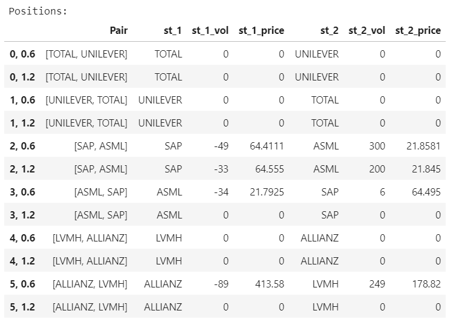

# 1.4. Hedging

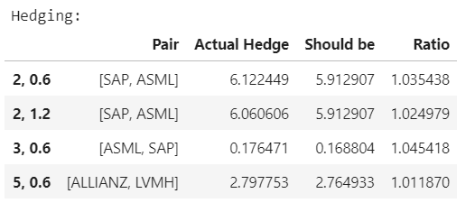

# 1.5. Profits

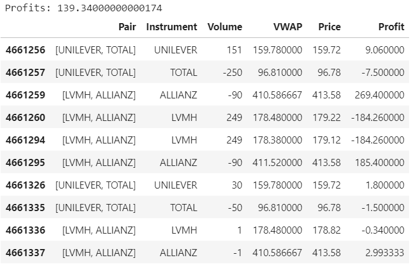

# 1.6. Hedging Performance

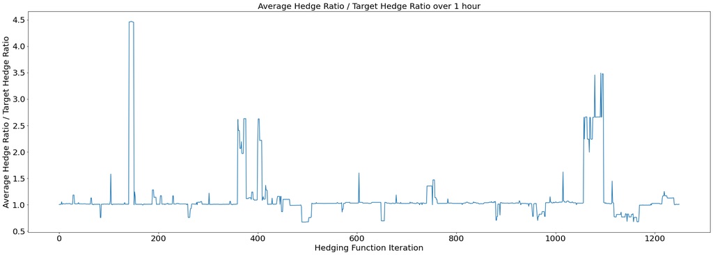

```python
fig, ax = plt.subplots(figsize=(30, 10))
ax.plot(range(len(av_hedge[:1250])), av_hedge[:1250])
ax.set_title('Average Hedge Ratio / Target Hedge Ratio over 1 hour', fontsize=20)
ax.set_xlabel('Hedging Function Iteration', fontsize=20)
ax.set_ylabel('Average Hedge Ratio / Target Hedge Ratio', fontsize=20)
ax.tick_params(axis='both', which='major', labelsize=20)
```

# 1.7. Strategy Performance

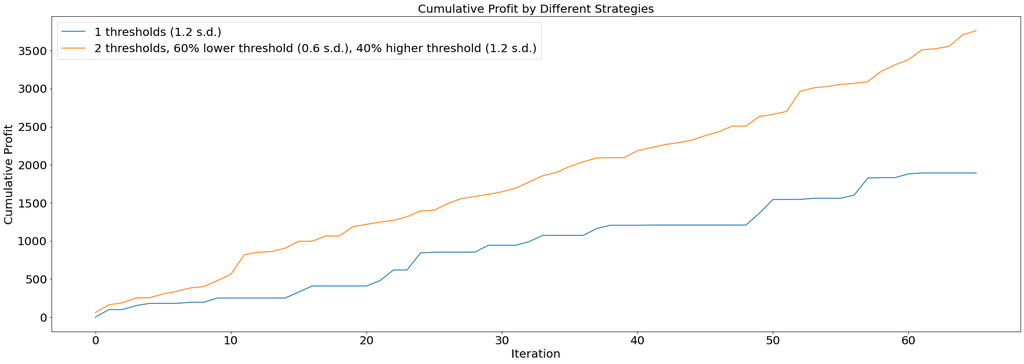

```python
fig, ax = plt.subplots(figsize=(30, 10))
ax.plot(range(len(test_1[:66])), test_1[:66], label='1 thresholds (1.2 s.d.)')
ax.plot(range(len(test_2[:66])), test_2[:66], label='2 thresholds, 60% lower threshold (0.6 s.d.), 40% higher threshold (1.2 s.d.)')
ax.set_title('Cumulative Profit by Different Strategies', fontsize=20)
ax.set_xlabel('Iteration', fontsize=20)
ax.set_ylabel('Cumulative Profit', fontsize=20)
ax.tick_params(axis='both', which='major', labelsize=20)
ax.legend(prop={'size': 20})
```

# 2.1. Difficulties and challenges we encountered: Overview

# 2.2. Difficulties and challenges we encountered: Threshold trade-off

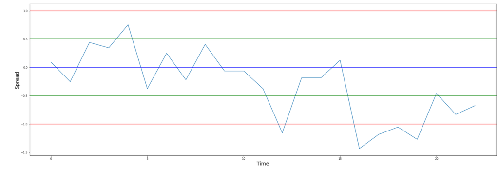